[figure not shown]

# Introduction to Python for Data Science

# Lecture 01: Welcome to the (Python) Jungle

## Student Name:

## Student ID:

## 0.1.0 About Introduction to Python

Introduction to Python is brought to you by the **Centre for the Analysis of Genome Evolution & Function (CAGEF)** bioinformatics training initiative. This course was developed based on feedback on the needs and interests of the Department of Cell & Systems Biology and the Department of Ecology and Evolutionary Biology.

The structure of this course is a code-along style so it is 100% hands on! A few hours prior to each lecture, the materials will be avaialable for download at [QUERCUS](https://q.utoronto.ca/). The teaching materials will consist of a Jupyter Lab Notebook with concepts, comments, instructions, and blank spaces that you will fill out with Python code along with the instructor. Other teaching materials include a live version of the notebook, and datasets to import into Python - when required. This learning approach will allow you to spend the time coding and not taking notes!

As we go along, there will be some in-class challenge questions for you to solve either individually or in cooperation with your peers. Post lecture assessments will also be available (see syllabus for grading scheme and percentages of the final mark) through [DataCamp](https://Datacamp.com) to help cement and/or extend what you learn each week.

### 0.1.1 Where is this course headed?

We'll take a blank slate approach here to Python and assume that you pretty much know *nothing* about programming. From the beginning of this course to the end, we want to get you from some potential scenarios:

- A pile of data (like an excel file or tab-separated file) full of experimental observations and you don't know what to do with it.
- Maybe you're manipulating large tables all in excel, making custom formulas and pivot table with graphs. Now you have to repeat similar experiments and do the analysis again.
- You're generating high-throughput data and there aren't any bioinformaticians around to help you sort it out.
- You heard about Python and what it *could* do for your data analysis but don't know what that means or where to start.

and get you to a point where you can:

- Format your data correctly for analysis
- Produce basic plots and perform exploratory analysis
- Make functions and scripts for re-analysing existing or new data sets
- Track your experiments in a digital notebook like Jupyter!

### 0.1.2 How do we get there? Step-by-step.

In the first two lessons, we will talk about the basic data structures and objects in Python, get cozy with the Jupyter Notebook environment, and learn how to get help when you are stuck. Because everyone gets stuck - a lot! Then you will learn how to get your data in and out of Python, how to tidy our data (data wrangling), subset and merge data. We'll take a break from data wrangling to spend our fourth lecture learning how to generate exploratory data plots. Then we'll slide into using the power of python and programming to use flow control before visiting text manipulation techniques in lectures 5 and 6. Data cleaning and string manipulation is really the battleground of coding - getting your data into the format where you can analyse it. Lastly, we will learn to write customized functions to help scale up your analyses.

[figure not shown]

The structure of the class is a **code-along** style: It is fully hands on. At the end of each lecture, the complete notes will be made available in a PDF format through the corresponding Quercus module so you don't have to spend your attention on taking notes.

### 0.1.3 What kind of coding style will we learn?

There is no single path correct from A to B - although some paths may be more elegant, or more efficient than others. With that in mind, the emphasis in this lecture series will be on:

1. **Code simplicity** - learn helpful functions that allow you to focus on understanding the basic tenets of good data wrangling (reformatting) to facilitate quick exploratory data analysis and visualization.
2. **Code readability** - format and comment your code for yourself and others so that even those with minimal experience in R will be able to quickly grasp the overall steps in your code.
3. **Code stability** - while the core Python code is relatively stable, behaviours of functions can still change with updates. There are well-developed packages we'll focus on for our analyses. Namely, we'll become more familiar with the `pandas` series of packages for working with tabular data. This resource is well-maintained by a large community of developers. While not always the "fastest" approach this additional layer can help ensure your code still runs (somewhat) smoothly later down the road.

## 0.2.0 Lecture objectives

This week will be your crash-course on Jupyter notebooks and the basic principles of Python. This is the beginning of a 7-week journey so we'll ease into things by introducing the format, and going over the very basics of Python to start.

At the end of this lecture we will have covered the following topics:

1. Working with Jupyter notebooks and best coding practices.
2. Variables and how to assign them.
3. Packages and how to import and use them.
4. Data types in Python and the basics of working with them.

## 0.3.0 A legend for text format in Jupyter markdown

`grey background` - a package, function, code, command or directory. Backticks are also use for in-line code.  
*italics* - an important term or concept or an individual file or folder  
**bold** - heading or a term that is being defined  
blue text - named or unnamed hyperlink

`...` - Within each coding cell this will indicate an area of code that students will need to complete for the code cell to run correctly.

**Blue box:** A key concept that is being introduced

**Yellow box:** Risk or caution

**Green boxes:** Recommended reads and resources to learn Python

**Red boxes:** A comprehension question which may or may not involve a coding cell. You usually find these at the end of a section.

## 0.4.0 Lecture and data files used in this course

### 0.4.1 Weekly Lecture and skeleton files

Each week, new lesson files will appear within your JupyterHub folders. We are pulling from a GitHub repository using this [Repository git-pull link](https://jupyter.utoronto.ca/hub/user-redirect/git-pull?repo=https%3A%2F%2Fgithub.com%2Fuoft-csb-datasci%2F2026-01-IntroPython&urlpath=tree%2F2026-01-IntroPython%2F&branch=main). Simply click on the link and it will take you to the University of Toronto JupyterHub. You will need to use your UTORid credentials to complete the login process. From there you will find each week's lecture files in the directory `/2026-01-IntroPython/Lecture_XX`. You will find a partially coded `skeleton.ipynb` file as well as all of the data files necessary to run the week's lecture.

Alternatively, you can download the Jupyter Notebook (`.ipynb`) and data files from JupyterHub to your personal computer if you would like to run independently of the JupyterHub.

### 0.4.2 Live-coding HTML page

A live lecture version will be available at [uoft-csb-datasci.github.io](https://uoft-csb-datasci.github.io/2026-01.IntroPython/index.html) that will update as the lecture progresses. Be sure to refresh to take a look if you get lost!

### 0.4.3 Post-lecture PDFs

As mentioned above, at the end of each lecture there will be a completed version of the lecture code released as a PDF file under the Modules section of Quercus.

# 1.0.0 What is Python?

[figure not shown]

Python is an open source, general purpose programming language created in 1989 by Dutch programmer Guido Von Rossum, and first released in 1991. From its conception, Python was meant to be elegant, powerful, and efficient, while easy to use by non-professional programmers. Python’s name comes from “Monty Python’s Flying Circus”, a popular British comedy back in the 1980’s, and references to the television show are often found among Python tutorials, manuals, and help sources (words like “spam” and “eggs” are references to Monty Python).

## 1.1.0 Generalities about Python

In addition to user friendliness, elegance and simplicity, the open-source nature of Python has allowed a community of thousands of developers to participate in the evolution of the language, making it one of the most popular coding languages and the lingua-franca for scripting in bioinformatics. Python is still one of the most sought-after skills in data science, software development, and pipeline engineering

### 1.1.1. Why Python?

As mentioned, Python is relatively simple to write, read, and therefore interpret, even by people that are not necessarily programming savvy; a contrasting difference with languages such as **C** and **C++**, that are difficult to read and write. Simplicity and efficiency are at the core of Python’s popularity, as users tend to spend more time writing code than dealing with complex grammar, syntax, or debugging (troubleshooting) code. These same characteristics have made Python very popular among data scientists. Since October 2021, Python has topped the [TIOBE index](https://www.tiobe.com/tiobe-index/) (The Importance of Being Earnest) as most professionally used and taught language in the world!

### 1.1.2. Python: An Object-Oriented Programming Language

Python is a *high-level*, **object-oriented programming** (OOP) language, meaning that:

1. Many operations happen “behind scenes” without the necessity of explicit, low-level instructions given by the user. This gives you the flexibility to build programs rapidly.
2. Everything in Python is an object (numbers, letters, spreadsheet-looking objects, etc.), and objects occupy space in the computer’s memory; but users do not need to worry about allocating memory space for each object created because Python takes care of that in the background.

In contrast, functional programming languages such as Fortran and C require users to often write complicated, long, and detailed sets of instructions so the computer knows exactly what to do, making those languages hard to write, read, and debug. (By the way, Python is mostly written in C!).

## 1.2.0 Coding in Jupyter Notebooks

The materials for this course have been prepared to work with Python **3.11.6** which runs off the University of Toronto JupyterHub.

Work with your Jupyter Notebook on JupyterHub will all be contained within a new browser tab with the address bar showing something similar to

`https://jupyter.utoronto.ca/user/assigned-username-hexadecimal/tree/2026-01.IntroPython`

All of this is running remotely on a University of Toronto server rather than your own machine.

You'll see a directory structure from your home folder:

ie `\2026-01.IntroPython\` and a folder to `Lecture_01_Intro_Python` within. Clicking on that, you'll find `Lecture_01.Intro.Python.JupyterHub.skeleton.ipynb` which is the notebook we will use for today's code-along.

### 1.2.1 Updating weekly lectures

Each week our JupyterHub directory for the course will be updated with a new lecture and materials. Prior to class you should update your JupyterHub version of the class repository by clicking on this [JupyterHub updater link](https://jupyter.utoronto.ca/hub/user-redirect/git-pull?repo=https%3A%2F%2Fgithub.com%2Fuoft-csb-datasci%2F2026-01-IntroPython&urlpath=tree%2F2026-01-IntroPython%2F&branch=main). Note that it's the same link every week used to update the lectures.

We'll also provide this link at the beginning of each class as a reminder along with a link to a live-updating version of the skeleton. As each lecture progresses, this HTML file will refresh with the code that we are inserting into various parts of our lecture. This way, if you get lost, you have a chance to catch up.

At the end of each class, a complete version of the lecture will be released on Quercus as a PDF for you to download so don't worry too much if you fall behind. We'll try to make sections of each lecture relatively independent so you can progress at points even if you do get lost.

## 1.3.0 Why is this class using Jupyter Notebooks?

We've implemented the class this way to reduce the burden of having to install various programs. While installation can be a *little* tricky, it's really not that bad. For this introduction course, however, you don't need to go through all of that just to learn the basics of coding.

Jupyter Notebooks also give us the option of inserting "markdown" text much like what you're reading at this very *exact* moment. So we can intersperse ideas and information between our learning code blocks.

There is, however an appendix section at the end of this lecture detailing how to install Jupyter Notebooks using the Anaconda environment. See section **7.0.0** for more information.

## 1.4.0 How to run Python code

There are several alternatives to run Python code in your computer, either as a single instruction or a set of several instructions called scripts.

### 1.4.1. Python in the command line

| Example image of the University of Toronto JupyterHub terminal |
| --- |

Perhaps the easiest and quickest way to start using Python is the interactive command line, also called interactive prompt, in a terminal. To try this option, open a terminal from your Jupyter Lab explorer under *New > Terminal* and type `python`. You should see three "greater than" symbols: `>>>`; they mean that Python is ready and waiting for instructions. Type `(5 + 6) * 4` and run that command (enter) to see the result. Once you are ready to exit, type `exit()` to get out of the interactive prompt.

The interactive prompt allows you to see the output of your Python code immediately. It is a quick way to do some statistical calculations or make a scatter plot. A major disadvantage of coding at the interactive prompt, though, is that the code you write will not be saved; there is no such a thing as a "**save as**" option. Your code runs and is executed, yes, but all those instructions that you wrote, if you want to save them, need to be manually *copied/pasted* to a text processor such as Notepad, Vim, or Nano. This is a major drawback as we tend to reuse the code we write. Additionally, a key concept in science is reproducibility, and what better way to make your analyses reproducible than saving a detailed list of the commands that you used to generate those results? Do not worry, however, because there are workarounds to overcome this limitation of interactive prompts, without tedious and error-prone copy/paste methods. Here is where Integrated Development Environments (IDEs) like Jupyter shine. Now, let us dive a bit more into IDEs.

### 1.4.2. Integrated Development Environments (IDE)

Integrated development environments are tools that assist in code development and they are available for almost every programming language. Many IDEs actually offer multilanguage support. IDEs offer Graphic User Interfaces (GUIs) that let you develop, edit, and browse Python programs, all from a single window. In addition to simplifying the task of saving the code that you write, IDEs also simplify the process of writing and debugging code (this last part is a huge advantage! In the next few lectures you will find out why). Examples of IDEs that support Python include [Atom](https://atom.io/), [Spyder](https://www.spyder-ide.org/), [Sublime](https://www.sublimetext.com/), [notepad<sup>++</sup>](http://csc.ucdavis.edu/~chaos/courses/nlp/Software/Windows/npp.html),and [Jupyter Lab](https://blog.jupyter.org/jupyterlab-is-ready-for-users-5a6f039b8906).

| The Anaconda Navigator provides access to many IDEs in a single interface |
| --- |

We will use **Jupyter Notebook** in this course, and it shares a lot of base kernel features with **Jupyter Lab** which automatically uses "syntax highlighting". It simply means that, as you write your code, the text editor starts pointing out issues that can break your code, such as misplaced commas, an open parenthesis that was not closed, or indentation issues (the latter is a big deal in Python). The main advantage of **Jupyter Lab** over other Python text editors is its support for markup capabilities via **Markdown**, a functionality that allows you to combine Python code with text to generate documents in various formats (e.g. .doc, .pdf, and HTML). For instance, the document that you are reading right now was initially created in **Jupyter Lab** using its Markdown functionality. To read more about Jupyter Lab's capabilities click [here](https://blog.jupyter.org/jupyterlab-is-ready-for-users-5a6f039b8906)

| Example image of a Jupyter Lab interface which can host multiple tabs for multiple projects |
| --- |

### 1.4.3. Python from scripts

A third alternative to run python code is using scripts. A script is simply a set of instructions written in Python and saved as a Python file, very easy to recognize because they have the extension **.py** (like in **file_name.py**). If you have created a script to run in a commandline setting, the first line usually looks something like:

`#!/usr/local/bin/python` or `#!/usr/bin/env python3`

Those two pieces of information - the extension and first line - let the computer know that the code in that file is a set of instructions that are written in Python and need to be interpreted as such. Those commands will be executed sequentially in their order of appearance unless otherwise indicated.

Scripts are a great resource to run multi-step programs that can take several hours to run, as you do not need to go back to your computer every few hours to run the next command. The script will take care of that for you.

## 1.5.0 The Jupyter notebook graphic user interface

Behind the scenes of each Jupyter notebook a programming kernel is running. For instance, depending on setup, our notebooks run a Python kernel to interpret each code cell as if it were written specifically for the Python language.

As we move from code cell to new code cell, all of the variables or objects we have created are stored within memory. We can refer to these as we run the code and move forward but if you overwrite or change them by mistake, you may to have rerun multiple cell blocks!

There are some options in the "Cell" menu that can alleviate these problems such as "Run All Above". If you think you've made a big error by overwriting a key object, you can use that option to "re-initialize" all of your previous code!

The run order of your code is also visible at the side of each code cell as **`[x]`**. When a code cell is still actively running it will be denoted as **`[*]`** since a number cannot be assigned to it. You'll also notice your kernel (top right of the menu bar) has a small circle that will be dark while running, and clear while idle.

**What are Interpreters and Kernels?:** We will, from time to time, mention things like interpreters and kernels. In our terminal example from **section 1.4.0**, once we activated *Python*, we were interacting directly with a **Python Interpreter**. It is essentially the piece of software that translates our "human-readable" Python *syntax* (aka language) into a "machine-readable" version of code. In our Jupyter Notebooks, we gain access to the interpreter through another layer of software known as the **kernel**. It essentially acts as a middle-man between us and the Python interpreter because additional syntax and output-rendering needs to happen for us to see our code-cell output. The kernel takes care of all the magical code-completion and additional interpretation for us!

### 1.5.1 Jupyter Notebook shortcuts

Your Jupyter notebook will run in two modes most of the time. You'll either be editing a cell by adding code or text to it, or you'll be in "Command Mode" where you can run or edit the properties of cells themselves. Below are some helpful shortcuts keys for navigating the command mode.

**Remember these friendly keys/shortcuts:**

- `Esc` to enter "Command Mode" which basically takes you outside of the cell.
- `Enter` to edit a cell.
- `Arrow` keys to navigate up and down (and within a cell).
- **`Ctrl`+`Enter` to run a cell (both code and markdown).**
- `Shift`+`Enter` to run the current cell **and** move to the next one below.
- `Ctrl`+`/` to quickly comment and uncomment single or multiple lines of code.
- **`Tab` can be used while coding to autocomplete variable, function and file names, and even look at a list of possible parameters for functions.**
- `Shift` + `L` to toggle line numbers within markdown and code cells.

In Command mode

- `a` insert a new cell __a__bove the currently selected cell.
- `b` insert a new cell __b__elow the currently selected cell. ** Note that cells are defaulted to code cells.
- `m` converts a section to a __m__arkdown cell.
- `y` converts a section to a __c__ode cell.
- `r` converts a section to a **r__aw** nbconvert cell. This is most helpful when wishing to preserve a code format without running it through the kernel.

### 1.5.2 Navigating the menu bar

If you can't remember your keyboard shortcuts, you can always access the same commands (and more!) through the menu bar. Note that these may vary between versions of Jupyter notebook.

- **File**: New, Open, Make a copy, Save as, Rename, Save and Checkpoint, Download as, Close and Halt.
- **Edit**: Cut, Copy, Paste, Delete, Split, Merge, Move, Find, Insert Image, nbextension config (alter your setting here)
- **View**: Toggle Header, Toggle Toolbar, Toggle Line Numbers
- **Insert**: Insert Cell Above/Below
- **Cell**: Run Cells, Run and Select Below, Run and Insert Below, etc. You can also clear and toggle cell output from here.
- **Kernel<sup>1</sup>**: Sometimes you need to restart or shut them down
- **Help**: General help options about Jupyter and references to widely used Python libraries such as NumPy, SciPy, and Pandas.

<sup>1</sup>kernels are separate processes to run code that are started by the server that runs your code.

### 1.5.3 Jupyter Dashboard tab

- **Files**: Directories and files in your current working directory.
- **Running**: A complete list of all the kernels currently active. You can end stalled notebooks from here too.
- **Nbextensions**: lists all of the configurations and extensions for your notebook (if you're running a custom installation)

## 1.6.0 Why would you want to use a Jupyter Notebook?

Depending on your needs, you may find yourself doing the following:

- Analysing data for your project using available packages
- Re-analysing data for your project
- Analysing multiple datasets for your project
- Collaborating on data and analyses for your project
- **Explaining** your data and analyses to a supervisor or collaborator!

Jupyter allows you to alternate between "markdown" notes and "code" that can be run or re-run on the fly.

Each data run and it's results can be saved individually as a new notebook or as new cells to compare data and small changes to analyses!

### 1.6.1 What is markdown language?

Markdown is a markup language that lets you write HTML and Java Script code in combination with other languages. This allows you to make html, pdf, and text documents that are combinations of text and code, enhancing reproducibility, a key aspect in scientific work. Having everything in a single place also boosts productivity during results interpretation - no need to go back and forth between tabs, pages, and documents. They can all be integrated in a single document, allowing for a more fluid narrative of the story that you are communicating to your audience (less distractions for you!). For example, the lines of code below and the text you are reading right now were created in Jupyter Lab's Markdown. (Do not worry about the Python code just yet. We will get there sooner than you think).

As mentioned, Jupyter also allows you to write in [LaTeX](https://www.latex-project.org/about/), a document preparation system to write mathematical notation. All it takes is to wrap LaTeX code between single dollar signs (\$) for inline notation or two double dollar signs (\$\$), one at the beginning of the equation and one at the end. For example, the equation **Yi = beta0 + beta1 xi + epsilon_i, i=1, ..., N** can be transformed into LaTeX code by adding some characters: **Y_i = \beta_0 + \beta_1 x_i + \varepsilon_i, i=1, \dots, N**. Now, if we use \$\$ before and after the LaTeX code, this is what we get:

$$ Y_i = \beta_0 + \beta_1 x_i + \varepsilon_i, i=1, \dots,N $$

See? Just like that!

We can make plots too:

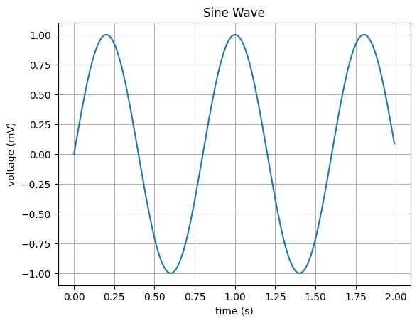

```python
# !pip install matplotlib
import pylab

t = pylab.arange(0.0, 2.0, 0.01) # Make a range from 0 to 2 in steps of 0.1
s = pylab.sin(2.5*3.14*t)        # Apply a sine function
pylab.plot(t, s)

pylab.xlabel('time (s)')
pylab.ylabel('voltage (mV)')
pylab.title('Sine Wave')
pylab.grid(True)
pylab.show()
```

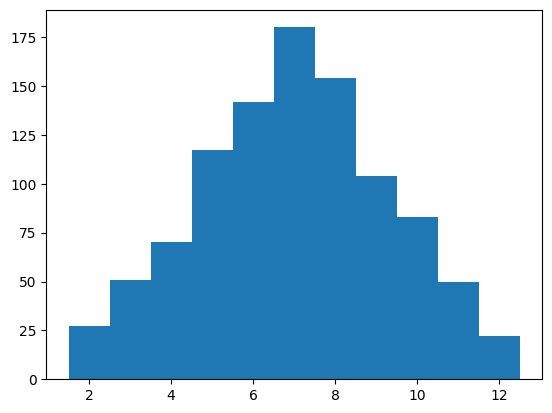

```python
import random

random.seed(113) # Set a random seed for reproducibility
samples = 1000
dice = []

for i in range(samples):
    total = random.randint(1,6) + random.randint(1,6)
    dice.append(total)

pylab.hist(dice, bins= pylab.arange(1.5,12.6,1.0))
pylab.show()
```

Here is an example of a table made in Markdown, showing some of the most popular Python libraries for data science:

| Library | Use |
| --- | --- |
| Pandas | Tabular-data processing |
| NumPy | Mathematical functions and objects manipulation |
| Matplotlib | Data visualization |
| SciPy | Statistical applications |

These are just a few examples of what you can do with Jupyter and Markdown. To find out more on how to get the best of Markdown, click [here](https://jupyter-notebook.readthedocs.io/en/stable/examples/Notebook/Working%20With%20Markdown%20Cells.html).

Once you are finished writing your Python code and interpreting those results in a Jupyter notebook, you can render the notebook into pdf, html, and many other formats. There are several ways to achieve this. The easiest option is to go to **File > Download as**, and select the format that you want for your output. You will be asked if you want to see the output or save it.

Jupyter notebooks can also be rendered via the terminal by running `jupyter nbconvert --to html my_notebook.ipynb`, where **my_notebook.ipynb** is the name of the Jupyter notebook to be converted into HTML. The new HTML file will have the same name of the original file but with the extension **html**. If you prefer your document as a pdf, replace **html** with **pdf** in the code above and that will do: `jupyter nbconvert --to pdf my_notebook.ipynb`.

So far, we covered what Python is, why it is very popular, and became familiar with Jupyter Notebook, including its markdown capabilities. We are **nearly** ready to start coding in Python.

## 1.7.0 Best-coding practices

| Credit: https://www.testbytes.net/blog/programming-memes/ |
| --- |

As in any other field, best practices have evolved over the years, and work as a set of standards that make processes more efficient and safer. In programming, these sets of standards are rather informal, unless the company where you work dictates otherwise, but are also intended to help generate better code and software. Here are some highlights about coding best practices.

### 1.7.1 Annotate your code with the `#` symbol

**Why bother?**

- "Can you rerun this analysis and but change X parameter?" - *Anonymous PI*
- "Can you make this plot, but with dashed lines, a different axis, with error bars?" - *Anonymous labmate*
- "Can I borrow your code?" - *Anonymous collaborator or officemate or PI*
- "Why is that object being sent to that function? What is it returning?" - *You, Me, and anyone reading your code*

**Your worst collaborator is potentially you in 6 days or 6 months. Do you remember what you had for breakfast last Tuesday?**

You can annotate your code for selfish reasons, or altruistic reasons, but please take the time to annotate your code.

**How do I start?**

- It is, in general, part of best coding practices to keep things tidy and organized.
- A hash-tag **`#`** will comment your text. Inside a code cell in a Jupyter Notebook or anywhere in a Python script, all text *after* a hashtag will be ignored by Python and by many other programming languages. It's very useful to add comments about changes in your code, as well as detailed explanations about your scripts.
- Put a description of what you are doing near your code at every process, decision point, or non-default argument in a function. For example, why you selected `k=6` for an analysis, or the Spearman over Pearson option for your correlation matrix, or quantile over median normalization, or why you made the decision to filter out certain samples.
- Break your code into sections to make it readable. Scripts are just a series of steps and major steps should be titled/outlined with your reasoning - much like when presenting your research.
- Give your objects *informative* names **that are not the same as function names**. More on that later...

**Comments may/should appear in three places:**

- At the beginning of your code: What's the objective of your script or this section of code?
- Above every function you create: Why did you have to write your own function versus those that are already available in package **x**?
- In-line or in-between lines of code: Why did you write that piece of code? What does it do? Why did you change a function's default parameters?

```python
#---------- Here's a section of code with a specific function ----------#

# Python knows this is a comment (notice the hash-tag).

# Comments can be added:
# At the beginning of the script, describe the purpose of your script and what you are trying to solve/achieve.

5 + 4 * 6 - 0 #In line: Describing a part of your code that is not obvious what it is for.
```

*Keep in mind that comments are useful in Python code that you can/want to save. If you are working at the command prompt, neither your code nor your comments will be saved.*

### 1.7.2 Naming conventions

Consistency in naming conventions will allow you to recognize at first glance variables (**Section 2.1.0**) and functions (**Section 3.0.0**) in your own code.

**Stylistically, you have the following options:**

- All lower case: e.g. **myfirstobject**
- Underscore-separated: e.g. **my_first_object**
- camelCase1: e.g. **myFirstObject** (Usually used for variable/objects and functions in object oriented programming)
- CamelCase2: e.g. **MyFirstObject** (Usually reserved for *Class* names in object oriented programming)

The most important aspects of naming conventions are being concise and consistent! Throughout this course you'll most often see the **underscore-separated** method to name variables.

## 1.8.0 Should I use Coding Companions?

Within 5 days of debuting in November 2022, [ChatGPT](https://chatgpt.com/) had 1 million users signed up. Since then, we have seen an explosion in the field of artificial intelligence with large language models and their utility across our society. LLMs are changing how we learn and practice [medicine](https://pubmed.ncbi.nlm.nih.gov/38639098/), [science](https://www.ncbi.nlm.nih.gov/pmc/articles/PMC10485814/), and even [art](https://www.forbes.com/sites/danidiplacido/2023/12/30/ai-generated-art-was-a-mistake-and-heres-why/) with some level of controversy. More importantly, these tools can help you fix, analyse and even generate code!

However, in the context of coding and data science, these tools are most useful when helping to decode, debug, and learn specific functions. However, **I recommend** a solid foundation in whatever you're trying to learn *before* relying on these tools. Having a base foundation of knowledge like understanding long- versus wide-format datasets or how tabular data can be stored in a `pandas.dataframe` will arm you with the ability to ask helpful questions. Knowing the difference between a variable and a function or an integer and a string will save you headaches when diagnosing code errors.

More importantly, once you CAN build rudimentary code, you can supply those portions of code to an LLM and ask it to interpret, debug or improve but you need to get there first. If you fail to understand the foundational ideas from this course, you will likely end up with haphazard-looking code that could be a nightmare for:

1. You to understand and adapt as a later time
2. Collaborators to modify or reuse
3. Instructors evaluating something like a term project worth 50% of your final mark...

We will, time permitting, aim to discuss how to use LLMs as coding companions at the end of our course but for now, give yourself the gift of hard-earned knowledge.

**Section 1.0.0 Comprehension Question:** What are the main differences between a Jupyter Notebook **code cell** and a **markdown cell**?.

## Section 1.0.0 comprehension answer:

# 2.0.0 Learning the basics of Python

### 2.0.1 Code cells are formatted to display the output from the last code call

When we make calculations in each code cell they produce a **single** output. This applies even if we produce *multiple* code lines that each, on their own, would generate an output. In a terminal you would be generating each call in a separate line and executing it. However, in Jupyter, the Python kernel only generates human-readable output for the *last* command call. **For the moment**, to remedy this, we will use the `print()` function to help see the output from multiple calls.

```python
# Compare the output of this code cell to the next!

5+6

10 + 2
```

```
12
```

```python
print(5 + 6)

print(10 + 2)

# Look we can use the ";" to perform multiple actions on the same line
print(5+6); print(10+2)

# The print function can even print multiple outputs in the same call!
print(5+6, 10+2)
```

```
11
12
11
12
11 12
```

Perhaps a disadvantage of this method is that the output is printed as a single line, which can sometimes make it harder to identify which output belongs to each command. Not a big deal for us right now.

## 2.1.0 Variables hold information

A `variable` is simply a name that substitutes for a value, where a value can be a letter, a number, or combinations of both. Variables allow you to store objects (remember that Python is object-oriented so **everything in Python is an object**), which makes your life easier because you do not need to re-write numbers and results, or even copy-paste them every time you need to use them in your code. By simply typing the variable that you created, you can have access to the results of your analyses or the data that you imported.

If you want to see the variable you just created, you need to explicitly use the `print()` function. The rules about variables in Python include:

- Starting with the letters `A-Z`, `a-z` or `_` (underscore).
- Cannot contain the `.` (period), `@`, `$`, or `%`.
- Must be unique in the scope it is declared (more on that later).
- Python is *case-sensitive* so `variable_name` and `Variable_Name` are completely different to the interpreter.
- It cannot be one of 35 reserve words.

They are called "reserved" because they already mean something in Python, and it will throw an error if you try to use those words to name variables. The reserved words are **and, del, from, None, True, as, elif, global, nonlocal, try, assert, else, if, not, while, break, except, import, or, with, class, False, in, pass, yield, continue, finally, is, raise, async, def, for, lambda, return**, and **await**.

Note that this list of reserved words can change with different versions of python so the easiest way is to ask the system about them instead. Let's use our another function `help()` while we're at it. We'll talk more about the `help()` function later in this lecture.

```python
# Use help to find information like "keywords"

help("keywords")
```

```
Here is a list of the Python keywords.  Enter any keyword to get more help.

False               class               from                or
None                continue            global              pass
True                def                 if                  raise
and                 del                 import              return
as                  elif                in                  try
assert              else                is                  while
async               except              lambda              with
await               finally             nonlocal            yield
break               for                 not
```

## 2.2.0 Variable assignment

Depending on how many objects are assigned at the time, variables can be classified as single- or multiple-assignment. **Note again that assignment of variables does not produce any output.**

### 2.2.1 Single-variable assignment

Only one variable is assigned at the time, as in the following example:

```python
# Assign your first variable here

variable_a = 5
print(variable_a)

# Assign a string to a variable. Note that we can also use spaces between our symbols like "="

variable_b = "python: snake or software"
print(variable_b)
```

```
5
python: snake or software
```

When you try to use a reserved word such as **`if`** to name a variable, Python will throw an **invalid syntax** error:

```python
# Attempt to assign a keyword to a variable

if = 5
```

```
  Cell In[7], line 3
    if = 5
       ^
SyntaxError: invalid syntax
```

Reserved words are easy to spot thanks to Jupyter's syntax highlight, as they will have a different color than the rest of your Python code.

Assigning variables to numbers, or naming a variable starting with a number, will also throw an error:

```python
# Name a variable using a number
5 = "This will not work"
```

```
  Cell In[8], line 2
    5 = "This will not work"
    ^
SyntaxError: cannot assign to literal here. Maybe you meant '==' instead of '='?
```

```python
# Name a variable starting with a number. Look at the syntax highlighting!
5again = "This will also not work"
```

```
  Cell In[9], line 2
    5again = "This will also not work"
    ^
SyntaxError: invalid decimal literal
```

### 2.2.2 Multiple-variable assignment

Python can also assign several variables simultaneously. Use commas to separate the different variables to be created (left side of the equal sign) and their values (right side). This will take the form of:

`var_a, var_b, var_c = value_a, value_b, value_c`

where values can range from numbers and strings to other objects - none of which have to be the same type!

**Caution:** The only condition to multi-variable assignment is that you must have the same number of elements on each side of the equal sign. There are two *additional* forms of assignment that don't exactly follow these rules but we'll *unpack* those as we learn more about Python.

```python
# Assign two values to two variables. Note that quotes change the object type!

multiple_assignment_1, multiple_assignment_2 = 5, "6"

# Print your newly assigned variables
print(multiple_assignment_1)
print(multiple_assignment_2)
```

```
5
6
```

**Caution:** Under the hood the behaviour of the **"="** sign can be context dependent and we'll learn more about this as we continue to explore Python.

**Section 2.0.0 Comprehension Question:** You can use the **type()** function to see the base type of an object (integer, string, etc.). Fix and run the following code so that you can determine what kind of object **multiple_assignment_2** is after assigning from our above code.

```python
# comprehension answer code 2.0.0
# Fix this code so we can see the type for multiple_assignment_2

type(multiple_assingmetn_2)
```

# 3.0.0 Functions, modules, and packages: What are they and why are they important?

| Functions perform all the heavy lifting for you - making your life easier! |
| --- |

## 3.1.0 Functions

We already used the functions: `print()`, `help()`, and `type()`. Functions are at the core of Python's capabilities and power. They are sets of instructions that Python recognizes and executes if no errors are detected. For example, there is already a function to calculate standard deviation so you do not need to define/create that function if you need it; you just use it. It's that simple.

Functions are accessed or *run* by including a set of parentheses after the function name ie `function_name()`.

## 3.2.0 Modules

As more and more functions are created by developers, these functions are better off kept in Python scripts (remember those files with the extension **.py**?). Each one of those scripts is called a **module**. Here is the definition of modules from Python's documentation:

- [...] a file containing Python definitions and statements. The file name is the module name with the suffix **.py** appended.

Simple, right? Now, things can get messy when we have too many python modules hanging around as individual entities; that is why modules are also organized into bigger collections called packages or libraries.

## 3.3.0 Packages or libraries

Packages are a way of structuring Python’s module namespace by using “dotted module names”. Packages exist to help organize modules and provide a naming hierarchy, which in turns keeps things organized in the same way that directories and subdirectories help you to organize files in your computer. The concept of libraries is what has made programming languages such as Python and R very popular, as any person can build packages and submit them for public use. This has allowed the participation of people from all disciplines in the development of packages relevant to their fields.

In order to use packages, they need to be installed by the user, except for those packages that are installed by default (built-in) when Python is installed. To see a list of all packages already installed in your computer, run `!pydoc3 modules` in Jupyter or `pidoc3 modules` in a terminal.

| There are many levels to how packages structured and grouped |
| --- |

### 3.3.1 Package installation can happen in Jupyter or with a terminal

In order to access the functions in a library, it must first be installed, a task that can be achieved from within Jupyter with the command:

`!pip install package_name` (`pip` is a package manager for Python).

**Key Concept:** Notice the exclamation mark at the beginning of the code? It makes a Jupyter cell behave as a command-line terminal, and is needed to install packages. Another way to install Python modules is by running the same code in a terminal (without the exclamation mark).

Here is your first task: Install *matplotlib* by running `!pip install matplotlib` from a code cell.

```python
# Install the matplotlib package
!pip install matplotlib
```

[output not shown]

In addition to the functions/modules/packages that you can install as add-ons, Python also has built-in functions. Some of those built-in functions perform basic mathematical operations such as `sum()`, `min()`, and `max()`; others are meant to be used by much more advanced users. For a complete list of built-in functions and what they do, click [here](https://docs.python.org/3/library/functions.html).

### 3.3.2 Importing packages with `import`

If it all goes well, the installation of a package is a one-time event (**except on JupyterHub**). Once packages are successfully installed, they must to be imported (loaded) into the global environment to use the modules and functions they contain. To import a given package, run the command `import` followed by the name of the package. Let us import `matplotlib`, a popular library for data visualization:

**Installing Packages on JupyterHub:** The Toronto Jupyter Hub runs as a server with a basic template. When we log-in a standardized version of the Jupyter Hub (aka an image) is instantiated and connected with our login. This version comes with many pre-installed packages for various languages like Python and R. When we install **new packages** these are installed onto the current image so that we can use them as needed. Upon logging out or restarting the server, our current updated image of the Jupyter Hub is erased and replaced with a fresh image. That means you'll need to install those packages all over again.

```python
# !pip install matplotlib
import matplotlib
```

Another option to import a package is using an shorter version of the packages name, called an alias:

`import`**`module_name`**`as`**`alias`**

Aliases are optional but very handy when modules have long names (you will see why). The `matplotlib` library can then be imported as `mp` (or any alias you want!)

**Key Concept:** Once a module is imported, you can use its **alias** to invoke functions from that library/module.

```python
# import matplotlib and then give it an alias

import matplotlib as mp
```

## 3.4.0 Using packages, modules, and functions

Things are starting to get a bit confusing with all these concepts and definitions so here is a brief recap: **functions** are the pieces of code that actually do the job in Python; they live in Python scripts called modules, which in turn live in packages, which are collections of modules. This hierarchy helps to keep things organized.

As per their definition, packages can contain many modules, and often we only need to access one or two of those modules. There are two ways to import specific modules: **dot notation** and **`from`**. This is how we import the `pyplot` module from `matplotlib` using **dot notation**:

```python
# Import using the dot notation and add an alias

import matplotlib.pyplot as plt
```

Note the use of `.` to separate our sections within the package. Our other method is with **`from`**:

```python
# Use the from keyword to import a module from the matplotlib package

from matplotlib import pyplot as plt
```

Both codes achieve the same results. Let us use the `pyplot` module from the `matplotlib` library:

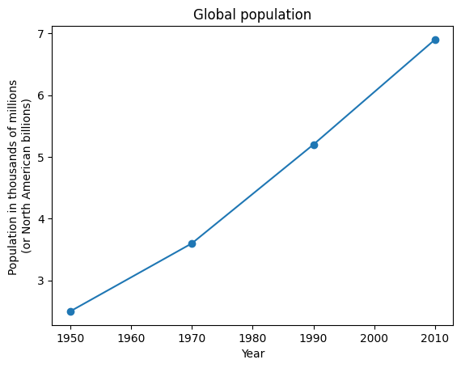

```python
# Import the pyplot module from matplotlib
# import matplotlib.pyplot as plt

year = [1950, 1970, 1990, 2010]
population = [2.5, 3.6, 5.2, 6.9]

# Use the plt functions to generate a plot
# Notice how we prefix our functions with "plt."?

plt.plot(year, population, "o-")
plt.title("Global population")
plt.xlabel("Year")
plt.ylabel("Population in thousands of millions \n(or North American billions)")
plt.show()
```

Now you can see why it is handy to use short aliases! Otherwise we would have typed *matplotlib.pyplot* five times.

## 3.5.0 Documentation

Packages, modules, and functions are accompanied by documentation that describe what they do, what type of data they use, and, of course, how to use them. Documentation can be accessed via the `help()` function as we've seen previously:

```python
# Find out more about the matplotlib package

help(matplotlib)
```

```
Help on package matplotlib:

NAME
    matplotlib - An object-oriented plotting library.

DESCRIPTION
    A procedural interface is provided by the companion pyplot module,
    which may be imported directly, e.g.::

        import matplotlib.pyplot as plt

    or using ipython::

        ipython

    at your terminal, followed by::

        In [1]: %matplotlib
        In [2]: import matplotlib.pyplot as plt

    at the ipython shell prompt.

    For the most part, direct use of the explicit object-oriented library is
    encouraged when programming; the implicit pyplot interface is primarily for
    working interactively. The exceptions to this suggestion are the pyplot
    functions `.pyplot.figure`, `.pyplot.subplot`, `.pyplot.subplots`, and
    `.pyplot.savefig`, which can greatly simplify scripting.  See
    :ref:`api_interfaces` for an explanation of the tradeoffs between the implicit
    and explicit interfaces.

    Modules include:

    :mod:`matplotlib.axes`
        The `~.axes.Axes` class.  Most pyplot functions are wrappers for
        `~.axes.Axes` methods.  The axes module is the highest level of OO
        access to the library.

    :mod:`matplotlib.figure`
        The `.Figure` class.

```

[output cut: 1010 more lines]

```
    color_sequences = <matplotlib.colors.ColorSequenceRegistry object>
    colormaps = <matplotlib.cm.ColormapRegistry object>
    defaultParams = {'_internal.classic_mode': [False, <function validate_...
    rcParams = RcParams({'_internal.classic_mode': False,
         ...nor.widt...
    rcParamsDefault = RcParams({'_internal.classic_mode': False,
         ...n...
    rcParamsOrig = RcParams({'_internal.classic_mode': False,
         ...nor....

VERSION
    3.8.2

FILE
    c:\users\mokca\anaconda3\envs\csbjupyter\lib\site-packages\matplotlib\__init__.py
```

It contains a lot of information and very specialized jargon that will become easier to understand as you get more exposure to Python and programming in general. In addition to these very detailed documents, more beginner-friendly options are available on the internet in the form of "user guides" and "tutorials". If you are new to Python, and more so to programming, I would encourage you to start with user guides and tutorials; they are easier/quicker to digest and apply. Documentation will be available for consultation if at any point you need a deeper understanding of a function, module, or package.

## 3.6.0 Importing one more library

Now that we know a little more about libraries, packages and functions, we're going to update our Jupyter notebooks by accessing the Python core via `IPython.core.interactiveshell`. From there we'll change a value to alter the behaviour of how expression output is displayed with the `ast_node_interactivity` option.

The default value is `last_expr` but we can also choose from: `all`, `last`, `none`, and `last_expr_or_assign`

```python
# Access options from the iPython ...
from IPython.core.interactiveshell import InteractiveShell

# Change the value of ast_node_interactivity to "all"
InteractiveShell.ast_node_interactivity = "all"
```

**Section 3.0.0 Comprehension Question:** From the matplotlib package, which module is used for colour specifications and making colourmaps?

## Section 3.0.0 comprehension answer:

# 4.0.0 Data types

As mentioned before, Python is an object-oriented programming language, thus **everything in Python is an object**. Among those objects we find so-called **data types**, which are the basic units with which we work and operate. In this section we will cover three of them: Numbers, strings, and booleans.

## 4.1.0 Numbers

Here are some examples of number types mixed with variables - a concept introduced earlier in **section 2.2.0**:

```python
# Integers
intVar_1 = 5
intVar_2 = 90
intVar_3 = 14000

# Use tab for autocompletion. It saves you from making typos and, even better, saves you time hunting down those typos!
# print(intVar_1, intVar_2, intVar_3)
intVar_1
intVar_2
intVar_3
```

```
5
```

```
90
```

```
14000
```

Make sure that you **DO NOT** add commas to indicate place-holders (ie thousands, millions, etc.), otherwise you will get a completely different result. More importantly, you do not get any errors or warnings! See the example below:

```python
# See what happens when we use comma separators in our numbers!
intVar_4 = 13,000

intVar_4 # variable_d is a variable with two elements because of the comma

type(intVar_4) # it is assigned as a "tuple" (more on that later)
```

```
(13, 0)
```

```
tuple
```

**What just happened?** We won't explore the idea of tuples until **lecture 2** but we basically made a small kind of list of numbers! In Python the comma **(,)** can be used to generate different kinds of data structures (objects that hold multiple pieces of information).

So what do floats or floating-point numbers look like?

```python
# Floats
floatVar_1 = 1.5
floatVar_2 = 45.11
floatVar_3 = 3000.5

# Notice how Python assigns these number types automatically?
floatVar_1
floatVar_2
floatVar_3
```

```
1.5
```

```
45.11
```

```
3000.5
```

If you are not sure or you forgot a variable's data type, just use the `type()` function and pass the variable as an argument.

**What is the difference between an argument and a parameter?** *Arguments* make reference to information that is passed on to a function i.e. the values typed inside the parenthesis of a function. *Parameters* refer to the variables listed in the definition of a function. Arguments are assigned to parameters when a function is called.

```python
# Check the typing of some of our variables
type(intVar_1)
type(floatVar_1)
```

```
int
```

```
float
```

### 4.1.1 Perform standard mathematical operations on numeric variables

Now that we have some variables, we can use some mathematical operations and see what we get. Note the standard symbols for mathematical operations are used in Python:

- `+`: addition
- `-`: subtraction
- `*`: multiplication
- `/`: division

```python
# Basic operations
intVar_1 + floatVar_1 # Addition of intVar_1 and floatVar_1
floatVar_1 * intVar_2 # Multiplication of floatVar_1 and intVar_2
intVar_3 / floatVar_3 # Division of intVar_3 and floatVar_3
floatVar_2 - intVar_2 # Substraction of floatVar_2 and intVar_2
```

```
6.5
```

```
135.0
```

```
4.665889018496917
```

```
-44.89
```

### 4.1.2 Use the `**` operator to calculate exponentiation

In some other languages you may use the `^` to represent exponents but Python can parse through the double-asterisk `**` to perform exponentiation. Depending on context, it can have additional meanings/functions as well.

```python
# Exponentiation
floatVar_2 ** 3
```

```
91794.884831
```

### 4.1.3 Use the `sqrt()` function to determine square roots

A common mathematical operation you may also wish to perform is determining the square root of a value. To accomplish this use the `sqrt()` function. Let's try it on the product of `variable_1` and `variable_a`.

```python
# Squared root
sqrt(floatVar_1 * intVar_1)
```

```
---------------------------------------------------------------------------
NameError                                 Traceback (most recent call last)
Cell In[27], line 2
      1 # Squared root
----> 2 sqrt(floatVar_1 * intVar_1)

NameError: name 'sqrt' is not defined
```

Why did we get an error and what does it mean? Look it up on the internet. What did you look for and what did you find?

```python
# I you can't find any information about a function, what does this likely mean?
help(sqrt)
```

```
---------------------------------------------------------------------------
NameError                                 Traceback (most recent call last)
Cell In[28], line 2
      1 # I you can't find any information about a function, what does this likely mean?
----> 2 help(sqrt)

NameError: name 'sqrt' is not defined
```

```python
# Squared root calculation requires the math package!
import math
sqrt(floatVar_1 * intVar_1)
```

```
---------------------------------------------------------------------------
NameError                                 Traceback (most recent call last)
Cell In[29], line 3
      1 # Squared root calculation requires the math package!
      2 import math
----> 3 sqrt(floatVar_1 * intVar_1)

NameError: name 'sqrt' is not defined
```

If **math** is already imported, why is it still not working?

```python
# How can we find a way to access it?
help(math.sqrt)
```

```
Help on built-in function sqrt in module math:

sqrt(x, /)
    Return the square root of x.
```

```python
# Remember the dot notation:
variable_root = math.sqrt(floatVar_1 * intVar_1)

variable_root

# Or you could use our knowledge of math:
(floatVar_1 * intVar_1)**(1/2)
```

```
2.7386127875258306
```

```
2.7386127875258306
```

That is better. Now, that number is awfully long. Round it up to two digits:

```python
round(variable_root, 2)
```

```
2.74
```

**Section 4.1.0 Comprehension Question:** Use Python code to calculate the remainder of 10 divided by 2. Remember: The remainder is what is left over after a division. Tip: Look it up on the internet!

```python
# comprehension answer code 4.1.0
# look up how to calculate the remainder in Python
```

That is enough for numbers for now. Let us move to other data types

## 4.2.0 Strings

Strings are just text or, more *technically* speaking, characters. They are called strings simply because they resemble strings of characters. Things like words, names, and also numbers, can be strings if coded properly.

Really anything wrapped in `"`quotes`"` or `'`quotes`'` can be interpreted as a string.

```python
# Generate your first strings

stringVar_1 = "My first string!"
stringVar_1

stringVar_2 = 'And another string!'
stringVar_2
```

```
'My first string!'
```

```
'And another string!'
```

Notice that Python will output our strings using single quote. Strings can also be made up of numbers, as long as the numbers are wrapped between single or double quotes:

```python
stringVar_3 = '123'

stringVar_3

# What is the type of this variable?
type(stringVar_3)
```

```
'123'
```

```
str
```

### 4.2.1 Concatenate strings using the `+` operator

While the `+` operator may have a specific function when dealing with numbers, **its function is actually context-based**. When running a command, Python will interpret certain operators based on the objects being provided. In the case of strings, Python will recognize that strings are present on both sides of the operator and concatenate them together.

```python
stringVar_1 + " " + stringVar_2 # Notice the space in between the quotes
```

```
'My first string! And another string!'
```

### 4.2.2 Subset strings by their index (position)

Every string can be considered as a line of characters where each is assigned a position. These positions are called the **index** and in Python we start with `0` as the first position. This is known as "**zero indexing**". For the novice and seasoned programmer this can lead to some headaches especially when switching between languages!

**Check out:** [The off-by-one error!](https://en.wikipedia.org/wiki/Off-by-one_error)

We can subset strings using indexing, which simply means calling the elements present based on their numerical position in our variable. In Python, indexation starts at 0, hence the name "**zero indexing**".

Knowing this, we can subset strings using their index. This train of thought will also apply later to more complex data structures!

For example, the letter "**M**" in `stringVar_1` is at the index `0`. Spaces, denoted by a space within quotes (" "), are also accounted for when indexing. Here are the indices for all the elements in `stringVar_1`:

| Character position | 1 | 2 | 3 | 4 | 5 | 6 | 7 | 8 | 9 | 10 | 11 | 12 | 13 | 14 | 15 | 16 |
| --- | --- | --- | --- | --- | --- | --- | --- | --- | --- | --- | --- | --- | --- | --- | --- | --- |
| **Index position** | 0 | 1 | 2 | 3 | 4 | 5 | 6 | 7 | 8 | 9 | 10 | 11 | 12 | 13 | 14 | 15 |
| **character** | M | y | <space> | f | i | r | s | t | <space> | s | t | r | i | n | g | ! |

To access specific elements of a string, we use the index operator denoted by a position within a set of squared brackets `[<index>]`:

```python
# access the first element of string_1

stringVar_1[0]
```

```
'M'
```

### 4.2.2.1 Slice your strings to get multiple character subsets

Accessing elements from a string is that simple! You can also access a range of those elements by using a colon `:` in between two indices. This is known as **slicing** and we can use the short `[start:end]` or full notation `[start:end:step]` which we will cover more of in **lecture 6**!

Now, we are interested in accessing only the word "**first**" from `stringVar_1`, which ranges from index 3 to 7. How would you do it?

```python
stringVar_1[3:7]
```

```
'firs'
```

**Caution:** Why is the word **"first"** incomplete? Because the Python uses slicing more specifically as **[start (*inclusive*):end (*exclusive*)]**. Try it again, now with **3:8**. When it comes to thinking about the location of an end-index, simply count the number of characters and use that number OR use the *character* position!

```python
# watch out for 0 indexation and inclusive:exclusive ranges!!!!!!!!!!!!!!!

stringVar_1[3:8]
```

```
'first'
```

### 4.2.2.2 Access elements of a string based on relative distance to the end

The elements of a string can also be accessed from the end by using negative integers, either to access single values or ranges. Note, however, that there is no zero-indexation in reverse so the last character in a string is at `-1`.

```python
# In reverse order, there is no 0 indexation!!!!!!!!!
stringVar_1[-1]

# But watch out! Our slicing rules still apply!
stringVar_1[-5:-1]
```

```
'!'
```

```
'ring'
```

As you can see from above, we cannot slice to the end of a string using the `start:end` notation because of its `[inclusive:exclusive]` behaviour.

### 4.2.2.3 Short-cut your slicing notation

Python allows us to short-hand our slicing notation as well by using default values/behaviours in unused arguments. This can also be called a half-open interval and could be a reason why slicing follows the `[inclusive:exclusive]` behaviour. Let's see how this half-open behaviour works with `stringVar_1`.

```python
# Retrieve the first 5 elements of string_1
stringVar_1[0:5]
stringVar_1[:5]

# Retrieve everything after the 5th element
stringVar_1[5:]

# Not the same!
stringVar_1[5:-1]

# Retrieve the last 5 elements of string_1
stringVar_1[-5:]

# Not the same!
stringVar_1[-5:-1]

# What does this return?
stringVar_1[5:6]
```

```
'My fi'
```

```
'My fi'
```

```
'rst string!'
```

```
'rst string'
```

```
'ring!'
```

```
'ring'
```

```
'r'
```

Time for booleans!

## 4.3.0 Booleans

Booleans are binary categories such as `False` or `True`, yes or no, 1 or 2 (ordinal). Despite their simplicity, booleans are very powerful when used in functions as they can make decisions for you: If the output of a command is `True`, do *x*, if `False`, do *y*.

### 4.3.1 Booleans and conditionals

Booleans go hand-in-hand with what are called "conditional" arguments. Here are some examples:

```python
5 == 4 # Exactly equal. == is not assignment but assessing if the two sides are exactly the same

5 != 4 # Different than

5 > 4 # Greater than

5 < 4 # Lesser than

5 >= 4 # Greater or equal than

5 <= 4 # Lesser or equal than
```

```
False
```

```
True
```

```
True
```

```
False
```

```
True
```

```
False
```

**Key Concept:** By combining booleans with conditionals you can get Python to make decisions for you, which in turn simplifies your code and your programming life at the same time. We will see the real power behind booleans in **lectures 5 (flow control) and 7 (user-defined functions)**.

## 4.4.0 Type conversion or coercion

Sometimes we wish to change one data type to another. In the process of certain commands, Python may automatically complete these type conversions, which is also known as **coercion**. When we *explicitly* change from one data type to another, it is known as *casting*. You can cast between certain data types and also object types.

For example, data types can be converted *explicitly* using functions such `str()` and `int()`.

```python
# Define an integer as a string
stringVar_4 = "56"
type(stringVar_4)

# Cast that string into an actual integer
type(int(stringVar_4))
```

```
str
```

```
int
```

### 4.4.1 Cast your data types for the correct operations to occur.

If you are performing operations with `+` for instance, this kind of operator is interpreted to work with single data types rather than mixing them in the same command. Python doesn't really know *your* intentions as a programmer so you need to correctly guide it to make the right operation.

For example, converting strings into numbers allows us to operate with them mathematically.

```python
stringVar_5 = "50"
b = 10
c = int(stringVar_5) + b

print("The value of c is", c)
```

```
The value of c is 60
```

Therefore type conversion must be done *preceeding* an operation, otherwise errors will come up:

```python
stringVar_5 = "50"
b = 10
c = stringVar_5 + b  # Python will not coerce this for you!

print("The value of c is", c)
```

```
---------------------------------------------------------------------------
TypeError                                 Traceback (most recent call last)
Cell In[48], line 3
      1 stringVar_5 = "50"
      2 b = 10
----> 3 c = stringVar_5 + b  # Python will not coerce this for you!
      5 print("The value of c is", c)

TypeError: can only concatenate str (not "int") to str
```

### 4.4.1.1 Binary operations are evaluated left to right!

Let's take a quick trip under the Python hood. If we swap the order of our expression above, will the error be the same? In Python, binary operations are evaluated from left to right first even though the outcome of our code is still an error.

```python
stringVar_5 = "50"
b = 10
c = b + stringVar_5 # Python will not coerce this for you!

print("The value of c is", c)
```

```
---------------------------------------------------------------------------
TypeError                                 Traceback (most recent call last)
Cell In[49], line 3
      1 stringVar_5 = "50"
      2 b = 10
----> 3 c = b + stringVar_5 # Python will not coerce this for you!
      5 print("The value of c is", c)

TypeError: unsupported operand type(s) for +: 'int' and 'str'
```

### 4.4.1.2 Booleans can be cast as integers and vice versa

Similarly, booleans can also be converted into integers, where `False` is 0 (zero). Any number other than 0 is considered `True` (positive and negative).

```python
int(True) # True is 1

int(False) # 0 is false

bool(0) # 0 is equivalent to boolean False

bool(1) # 1 or any other number different than 0 are True
bool(1000)
bool(-1000)
```

```
1
```

```
0
```

```
False
```

```
True
```

```
True
```

```
True
```

**Section 4.4.1.2 Comprehension Question:** Use the following coding cell to calculate the sum of the following objects and variables: True, False, b, intVar_1, stringVar_4.

```python
# comprehension answer code 4.4.1.2
# Calculate the sum of True, False, b (variable), intVar_1, and stringVar_4
True + ...
```

| We will, however, certainly try our best with the remainder of the course! |
| --- |

# 5.0.0 Class summary

That's our first class on Python! You've made it through and we've learned about the following:

1. Best coding practices
2. Variable assignment
3. Installing, loading, and aliasing packages
4. Data types: numbers, strings, and booleans
5. Type conversion

## 5.1.0 Submit your completed skeleton notebook (2% of final grade)

At the end of this lecture a Quercus assignment portal will be available to submit your completed skeletons from today (including the comprehension question answers!). These will be due one week later, before the next lecture. Each lecture skeleton is worth 2% of your final grade but a **bonus 0.5%** will also be awarded for submissions made within 24 hours from the end of lecture (ie 1000 hours the following day).

1. From the Jupyter Notebook, select `File> Save Notebook` or use `ctrl + S`
2. Return to the Jupyter folder page (ie click on the top-left "jupyterhub" icon)
3. Locate your .ipynb file and click on the check box to its left side.
4. If it is still active it will have a green icon beside its name. Above the file list will be option to `Shut Down`. After clicking on this, you may re-select the file and above the file list choose `Download` to save to your local hard drive.
5. Upload your **`.ipynb`** file to the appropriate Quercus assignment portal.

| A sample screen shot for saving your completed skeleton notebooks |
| --- |

## 5.2.0 Post-lecture DataCamp assessment (5% of final grade)

Soon after the end of each lecture, a homework assignment will be available for you in [DataCamp](https://www.datacamp.com/). Your assignment is to complete chapters 1 (Python Basics, 700 possible points) and 3 (Functions and Packages, 950 possible points) from the Introduction to Python course. **This is a pass-fail assignment**, and in order to pass you need to achieve a least 1,238 points (75%) of the total possible points. Note that when you take hints from the DataCamp chapter, it will *reduce* your total earned points for that chapter.

In order to properly assess your progress on DataCamp, at the end of each chapter, please print a PDF of the summary. You can do so by following these steps:

1. Navigate to the **`Learn`** section along the top menu bar of DataCamp. This will bring up a sidebar menu where you can access the various courses you have been assigned under **`Assignments`** or you can scroll down on the page to find the **`My Assignments`** section. Click on the relevant chapter or course and this may bring you back to within the course itself.
2. You should now be on a Course Summary page (See figure below). You can expand each **chapter** of the course by clicking on the **`VIEW CHAPTER DETAILS`** link. **DO THIS FOR ALL COMPLETED SECTIONS ON THE PAGE!**
3. Select the visible text in the course Window (not from any top or side menus) using a click and drag technique. Using something like **Ctrl+A will not properly select the course text**.
4. Print the page from your browser menu and make sure you have "Selection Only" from the Settings options on the Print dialogue. Save as a single PDF. Note: if you don't select the text area correctly (at least in Google Chrome) you may not be able to print the full page. Your results should look something like this:

| A sample screen shot for one of the DataCamp assignments. You'll want to try and print off a single PDF of this section from **Learn > My Assignments** |
| --- |

You may need to take several screenshots if you cannot print it all in a single try. Submit the file(s) or a combined PDF for the homework to the assignment portal on Quercus. By submitting your scores for each section, and chapter, we can keep track of your progress, identify knowledge gaps, and produce a standardized way for you to check on your assignment "grades" throughout the course.

You will have until 09:59 hours on Tuesday, January 13th to submit your assignment (right before the next lecture).

## 5.3.0 Acknowledgements

**Revision 1.0.0**: materials prepared by Oscar Montoya, M.Sc. *Bioinformatician, Education and Outreach, CAGEF.*

**Revision 1.1.0**: edited and prepared for **CSB1021H S LEC0140**, 06-2021 by Calvin Mok, Ph.D. *Bioinformatician, Education and Outreach, CAGEF.*

**Revision 1.2.0**: edited and prepared for **CSB1021H S LEC0140**, 01-2022 by Calvin Mok, Ph.D. *Bioinformatician, Education and Outreach, CAGEF.*

**Revision 1.2.1**: edited and prepared for **CSB1021H S LEC0140**, 01-2023 by Calvin Mok, Ph.D. *Bioinformatician, Education and Outreach, CAGEF.*

**Revision 1.2.2**: edited and prepared for **CSB1021H S LEC0140**, 01-2024 by Calvin Mok, Ph.D. *Bioinformatician, Education and Outreach, CAGEF.*

**Revision 1.2.3**: edited and prepared for **CSB1021H S LEC0140**, 01-2025 by Calvin Mok, Ph.D. *Bioinformatician, Education and Outreach, CAGEF.*

**Revision 1.2.4**: edited and prepared for **CSB1021H S LEC0140**, 01-2026 by Calvin Mok, Ph.D. *Bioinformatician, Education and Outreach, CAGEF.*

# 6.0.0 Appendix 1: Class resources

## 6.1.0 Troubleshooting basics and getting help

The easiest and quickest ways of start getting help and debugging your code, is to simply copy/paste your error in search engines such as Google or DuckDuckGo. From those results, you can start narrowing down your search and even start using more specialized jargon that would give you more precise results. Below are some of the most common types of errors that you will encounter, along with recommendations to solve them:

- **File does not exist**: This error rises when your code is looking for a file in your current working directory but the file does not exist there. The **os** package is your friend to navigate the your computer's file system from within Python. Use **os.getcwd()** to check where you are working, type **os.listdir()** or the **Files** tab in the left pane to check that your file exists there, and **os.chdir** to change your directory if necessary.
- **Typos**: Python is case sensitive so always check that you've spelled everything right. Get used to use the *tab-autocompletion* feature when possible.
- **Open quotes, parentheses, brackets**: Jupyter highlights matching brackets, which helps to spot where parentheses or brackets are missing or not closed.
- **Data type**: Use commands like **type()** to check what type of data you have.
- **Unexpected answers**: To access the *help menu*, type **help(module.function)**. Make sure packages/modules are imported before using the **help()** function. Alternatively, use a question mark (?) followed by the module/function: **?module.function**
- **Function not found**: Make sure the package name is properly spelled, installed, AND imported.
- **Cheatsheets**: Meet your new best friends: [Cheatsheets](https://www.pythonsheets.com/)!

Beginners advice: At this level many people have had and solved your problem. Beginners get frustrated because they get stuck and take hours to solve a problem themselves. Go online and get help if books and **help()** did not help much.

*Finding answers online*

- 99% of the time, someone has already asked your question
- Google, Stack overflow, the [Python.org](https://www.python.org/about/help/), SEQanswers, Quora, ResearchGate, RSeek, twitter, even reddit
- Including the program, version, error, package, module, and function helps, be specific. Sometimes is useful include your operating system and version (Windows 10, Ubuntu 18, Mac OS 10, etc.).

*Asking a question*

- Summarize your question in the title (be concise and objective!).
- Introduce your question, how you ran into the problem, **and how you tried to solve it yourself**. If you have not done the bolded thing, do the bolded thing.
- Show enough of your code and data for other to try to reproduce the problem/error.
- Add tags that match your problem.
- Respond to the feedback and vote for the answered that you picked. People put in their free time to answer and help you.
- Take a look at [StackOverflow's tips on how to ask questions](https://stackoverflow.com/help/how-to-ask).

**Remember**: Everyone looks for help online **ALL THE TIME**. It is very common. Also, with programming there are multiple ways to come up with an answer, even different packages that let you do the same thing in different ways. You will work on refining these aspects of your code as you go along in this course and in your coding career.

## 6.2.0 Additional Resources

- https://www.coursera.org/learn/python
- https://www.coursera.org/specializations/python
- https://www.learnpython.org/
- https://www.datacamp.com/courses/intro-to-python-for-data-science
- https://www.datacamp.com/courses/intermediate-python-for-data-science

# 7.0.0 Appendix 2: Instructions for installing your own Jupyter Lab software

## 7.1.0 Jupyter Notebooks and the Python kernel

For this introductory course we will be teaching and running code for Python through Jupyter notebooks. In this section we will discuss

1. Installation of Jupyter (through Anaconda)
2. Updating the Python package
3. Starting up your Jupyter notebooks

### 7.1.1 Installing R and Jupyter Notebooks (via Anaconda3)

As of 2026-01-05, The latest version of Anaconda3 runs with Python 3.13

Download the OS-appropriate version from here https://www.anaconda.com/download

- You may need to sign up for a login/user account but this should be free
- Remember to choose the correct OS
- All versions should come with Python 3.13
- Windows:
  - Use the graphical installer
  - 64- vs. 32-bit is dependent on your version of windows
- MacOS:
  - It is likely easier to use the graphical installer vs. the command line version
- Unix:
  - Choose the 64-bit installer best for your linux OS

### 7.1.2 Updating Anaconda packages

To save time, we will update just our packages through the command line using the `Anaconda prompt`. You'll need to find the menu shortcut to the prompt in order to run these commands. Before class you should update all of your anaconda packages. This will be sure to get you the latest version of Jupyter notebook. Open up the Anaconda prompt and type the following command:

`conda update --all`

It will ask permission to continue at some point. Say 'yes' to this.

### 7.1.2.1 A quick note about Anaconda environments

You may find that for some reason or another, you'd like to maintain a specific Python-environment (or other) to work in. Environments in Anaconda work like isolated sandbox versions of Anaconda **within** Anaconda. When you generate an environment for the first time, it will draw all of its packages and information from the base version of Anaconda - kind of like making a copy. You can also create these in the Anaconda prompt. You can even create **new** environments based on specific versions or installations of other programs. For instance, we could have tried to make an environment for a separate programming language, R version 4.0.3, with the command

`conda create -n my_R_env -c conda-forge/label/main r-base=4.0.3=hddad469_3`

This would create a new environment with version **4.0.3** of R but the **base** version of Anaconda would retain version **3.6.1** of R. A small but helpful detail if you are unsure about newer versions of packages that you'd like to use.

Likewise, you can update and install packages in new environments without affecting or altering your base environment! Again it's helpful if you're upgrading or installing new packages and programs. If you're not sure how it will affect what you already have in place, you can just install them straight into an environment.

For more information: https://docs.conda.io/projects/conda/en/latest/user-guide/tasks/manage-environments.html#cloning-an-environment

### 7.1.3 Using the Anaconda navigator to make a Jupyter notebook

If you are inclined, the Anaconda Navigator can help you make a Python environment separate from the base, but you won't be able to perform the same fancy tricks as in the prompt, like installing new packages directly to a new environment.

**Note:** You should consider doing this only if you have a good reason to isolate what you're doing in Python from the Anaconda base packages. Perhaps you are installing a new or older version of the kernel to be compatible with a package you really want to use?

The Anaconda navigator is a graphical interface that shows all fo your pre-installed packages and give you access to installing other common programs like RStudio (we'll get to that in a moment).

- Open up your Anaconda Navigator
- Click on "Environments" in the left-hand pane.
- Click on the "Create" icon at the bottom of the middle pane
- You'll receive a dialog window for "Create New Environment".
- Name your environment like **"IntroPy"**
- Make sure the packages for **Python** (ie 3.9) is checked off.
- Click on the "Create" button and wait patiently for your environment to be created

You will now have a Python environment where you can install specific packages that won't make their way into your Anaconda base.

- After the environment is made, you can left-click on the green triangle of R-4-0-3 (for example)
- Choose "Open with Jupyter Notebook" from the dropdown menu.

You will likely find a shortcut to this environment in your (Windows) menu under the Anaconda folder. It will look something like **Jupyter Notebook (IntroPy)**

## The Center for the Analysis of Genome Evolution and Function (CAGEF)

The Centre for the Analysis of Genome Evolution and Function (CAGEF) at the University of Toronto offers comprehensive experimental design, research, and analysis services in microbiome and metagenomic studies, genomics, proteomics, and bioinformatics.

From targeted DNA amplicon sequencing to transcriptomes, whole genomes, and metagenomes, from protein identification to post-translational modification, CAGEF has the tools and knowledge to support your research. Our state-of-the-art facility and experienced research staff provide a broad range of services, including both standard analyses and techniques developed by our team. In particular, we have special expertise in microbial, plant, and environmental systems.

For more information about us and the services we offer, please visit https://www.cagef.utoronto.ca/.

[figure not shown]